# DATA 605 HW13

Josh Iden

2022-11-20

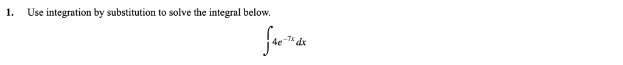

First move the constant out front,
$$= 4 * \int{e^{-7x}dx}$$
Substitute u,
$$u = -7x \rightarrow \frac{du}{dx}= -7 \rightarrow du = -7dx \rightarrow
dx = -\frac{1}{7}du$$
$$= 4 * \int{e^udx} \rightarrow e^u-\frac{1}{7}du \rightarrow
-\frac{1}{7}e^udu$$
$$= 4 * \int{-\frac{1}{7}e^udu}$$

Since
$$\int{e^udu} = e^u$$

$$= 4(-\frac{1}{7}e^u)$$
and
$$e^u = -7x$$
so

$$= 4(-\frac{1}{7}e^{-7x}) \rightarrow
-\frac{4}{7}e^{-7x}$$
Add a constant $C$ to the solution,

$$= -\frac{4}{7}e^{-7x} + C$$

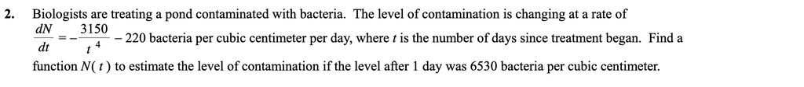

Given $t = 1$ and $N(1) = 6530$,

$\frac{dN}{dt} = -\frac{3150}{t^4}-220 = -3150t^{-4}-220$

$N( t ) = \int{-3150t^{-4}-220 dt}$

$= \frac{-3150t^{-3}}{-3} - 220t + C$

$N(t) = \frac {1050}{t^3} - 220t + C$

Since $N(1) = 6530$,

$6530 = \frac {1050}{1^3} - 220(1) + C$

$\Rightarrow 6530 = 1050 - 220 + C$ $\Rightarrow 5700 = C$

So,

$N(t) = \frac {1050}{t^3} - 220t + 5700$

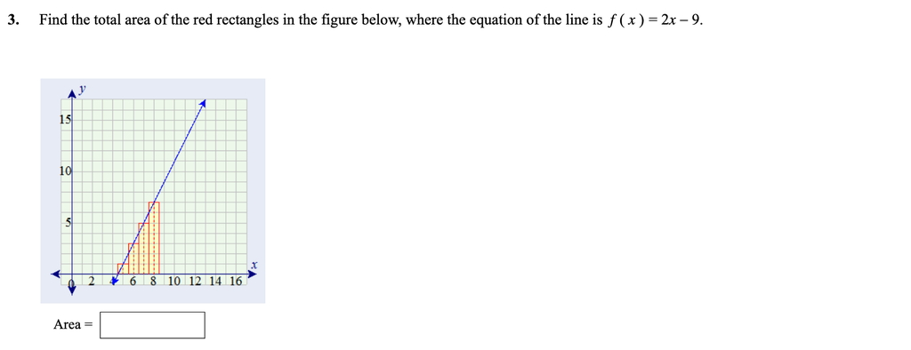

We’re looking for the rectangle that starts at x = 4.5 and ends at x = 8.5

$\int_{4.5}^{8.5} 2x - 9dx$

$=\left. \ {x^2} -9x \right|_{4.5}^{8.5}$

Area = $(8.5^2 - 9(8.5)) - (4.5^2 - 9(4.5)) \Rightarrow 16$

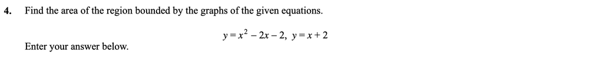

$x^2 - 2x -2 = x + 2 \Rightarrow$  
$x^2 - 3x - 4 = 0 \Rightarrow$ $(x - 4)(x + 1)$

$x = 4, x = -1$

$\int_{-1}^{4} (x+2)-(x^2-2x-2)dx \Rightarrow$  
$\int_{-1}^{4} -x^2+3x+4dx$

$=\left. \ \frac{-x^3}{3}+ \frac{3x^2}{2} +4x \right|_{-1}^{4}$

Area = $(\frac{-4^3}{3}+ \frac{3*(4)^2}{2} +4(4)) - (\frac{-(-1)^3}{3}+ \frac{3*(-1)^2}{2} +4(-1)) \Rightarrow$

$\frac{125}{6} = 20.83$

```r
y1 = function(x){x^2 - (2*x) - 2}
y2 = function(x){x + 2}

int_1 = integrate(y1, lower = -1, upper = 4)
int_2 = integrate(y2, lower = -1, upper = 4)

area = int_2$value - int_1$value
area
```

```
## [1] 20.83333
```

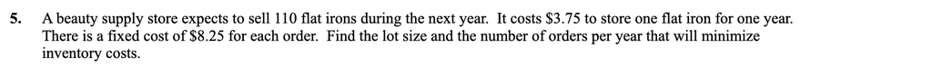

Let $x$ = number of irons per order.

Then $n$ = number of sales per year (110)

Then $\frac{n}{x}$ is the number of orders per year ($\frac{110}{x}$)

*Annual storage cost* is $3.75 * \frac{x}{2} = 1.875x$  
*Annual ordering cost* is $8.25 * \frac{110}{x} = \frac{907.5}{x}$  
*Annual inventory cost* $f(x)$ is *annual storage cost + annual ordering cost* $\Rightarrow 1.875x + \frac{907.5}{x}$

To find the minimum value, find $f'(x) = 0$

$f(x) = 1.875x + \frac{907.5}{x} \Rightarrow$

$f'(x) = 1.875 -\frac{907.50}{x^2}$  
$0 = 1.875 -\frac{907.50}{x^2}$  
$\frac{907.50}{x^2} = 1.875$  
$x = 22$

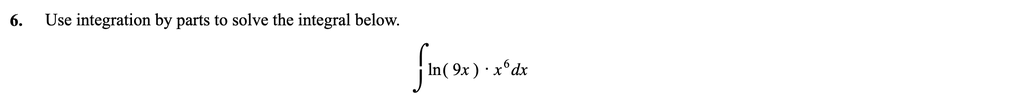

Let $u = ln(9x)$, then $\frac{du}{dx} = \frac{1}{x}$ and $du = \frac{1}{x}dx$,  
Let $dv = x^6$, then $v = \frac{1}{7}x^7$

Integrating,

$uv-\int vdu \Rightarrow$

$\frac{x^{7}ln(9x)}{7}-\int \frac{1}{7}x^{7}\frac{1}{x}dx$  
$\frac{x^{7}ln(9x)}{7}-\frac{1}{7} \int \frac{x^{7}}{x}dx$  
$\frac{x^{7}ln(9x)}{7}-\frac{1}{7}\int x^{6}dx$  
$\frac{x^{7}ln(9x)}{7}-\frac{1}{7}(\frac{x^{7}}{7})+C$  
$\frac{x^{7}ln(9x)}{7}-\frac{x^{7}}{49}+C$

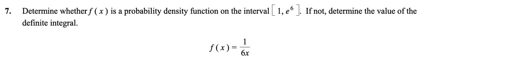

$\int_1^{e^6}\frac{1}{6x} dx$  
$= \frac{1}{6} ln(x)|_1^{e^6}$  
$= \frac{1}{6} ln(e^6) - \frac{1}{6} ln(1)$  
$= \frac{1}{6} * 6 - \frac{1}{6} * 0$  
$= 1$

The definite integral is 1, so it is on the interval $[1, e^6]$